# Notebook implementation showing GitHub Repository analysis for below use cases:

1. Recommend top-3 languages to the user based on the current usage of programming languages in the repositories which will show the future popularity. This future popularity is decided on the weight of each language considering the bytes of code written in it.
2. Recommend repositories to users based on the stars they have given until now.
3. We further do the Social Analysis of top-20 recommended repos and pick three users to show case our analysis and results.

# Use Case 1 Workflow

[figure not shown]

# Acquiring Data From BigQuery

Using Google's BigQuery we queried the data required from the tables that we have used for the analysis. Two major tables are languages and sample_repos.

```python
import os
import pandas
import numpy as np

from google.cloud import bigquery
client = bigquery.Client()

#Querying languages table
QUERY = """
        SELECT repo_name, language
        FROM `bigquery-public-data.github_repos.languages`
        LIMIT 300
        """

query_job = client.query(QUERY)

#Get results into the dataframe
languageData = query_job.to_dataframe()

#filtering repos which include only a single language
iterator = query_job.result(timeout=30)
rows = list(iterator)
rows = list(filter(lambda row: len(row.language)>1,rows))

#Printing first ten repositories
for i in range(10):
    print('Repository '+str(i+1))
    for j in rows[i].language:
        print(j[u'name']+': '+str(j[u'bytes'])+' bytes')
    print('')
print('...')
print(str(len(rows))+' repositories')
```

This table has only the repo_name and corresponding language that it holds. If see here, we have repo_name with user and repository details. We feature engineered this attribute as further for matrix factorization we need specific user_id for users and specific repo_id for repositories.

```python
languageData.head()
```

[output not shown]

# Listing the languages we got from above query after removing the repositories that have only one language

```python
#create dictionary of language names to matrix columns
names = {}
for i in range(len(rows)):
    for j in rows[i].language:
        if j[u'name'] in names:
            names[j[u'name']]+=1
        else:
            names[j[u'name']]=1

#filter out languages that only occur once
names = [n for n in names if names[n]>1]
# for i in range(10):
#     print(names[i])
# print('...')

#print some languages
name_to_index = {}
for j,i in enumerate(names):
    name_to_index[i] = j
print(str(len(names))+" languages")
```

# Repository-Language Matrix

We thought of creating a matrix where rows represent the repository and column represent a language to know the relationship between the repository and language. This resulted into a sparse matrix where many repositories did had or did not had that specific language.

This was the desicion making point where we decided to go ahead with matrix factorization due to the sparsity of the data of what we aim in first use case.

We created a matrix as mentioned above. Also as mentioned, the value in the matrix is the log of number of bytes in the repository in that particular language to consider the actual weight of the code written in that language for that repository.

Log also gives us the feature minimization (feature scaling) for the random size of the bytes information we have.

```python
from math import log

#create matrix
global mat
mat = np.zeros((len(rows),len(names)))
for i,row in enumerate(rows):
    #total = sum([log(lang[u'bytes']+1) for lang in row[1]])
    for lang in row.language:
        if lang[u'name'] in name_to_index and lang[u'bytes'] > 0:
            mat[i][name_to_index[lang[u'name']]] = log(lang[u'bytes'])
            #mat[i][name_to_index[lang[u'name']]] = log(lang[u'bytes']+1)/total
mat = mat[~np.all(mat==0,axis=1)]
```

# PCA

```python
from sklearn.decomposition import PCA
from matplotlib import pyplot as plt

%matplotlib inline

#compute PCA
n_components = min(50,len(names))
pca = PCA(n_components=n_components)
transformed = pca.fit_transform(mat)

#display result
evr = [1-sum(pca.explained_variance_ratio_[:i+1]) for i in range(len(pca.explained_variance_ratio_))]
plt.plot(range(1,n_components+1),evr)
```

[output not shown]

# Loss Function and Gradient

We define some useful functions.

init_mask: Create a mask matrix that indicates where Y has meaningful values.

loss: Sum-of-squares loss, with a regularization term to prevent overfitting. The matrices theta and X are multiplied to give a "best guess", which is then compared with the target matrix Y, but only in locations where a rating has been given.

gradient: Derivative of loss with respect to theta and X, with a regularization term.

These functions will be useful in performing gradient descent.

```python
filter_size = min(100,len(mat[0]))
mat = mat[:,range(filter_size)] if len(mat[0])>filter_size else mat #for speed


#This function gives us the sign function implementation for where the target Y is achieved
def init_mask(Y):
    f = np.vectorize(lambda x: 1 if x>0 else 0)
    return f(Y),len(Y),len(Y[0])


#This function implements the regularization parameter to minimize the overfitting
def loss(args,Y,mask,n_repos,n_langs,n_features,reg_param):
    theta = np.reshape(args[:n_repos*n_features],(n_repos,n_features))
    X = np.reshape(args[n_repos*n_features:],(n_langs,n_features))
    g = np.vectorize(lambda x: x*x)
    return 0.5*np.sum(np.multiply(g(np.subtract(np.matmul(theta,np.transpose(X)),Y)),mask))+reg_param/2*np.sum(g(args))


#This function implements gradient calculation in vectorized way
def gradient(args,Y,mask,n_repos,n_langs,n_features,reg_param):
    theta = np.reshape(args[:n_repos*n_features],(n_repos,n_features))
    X = np.reshape(args[n_repos*n_features:],(n_langs,n_features))
    X_grad = np.matmul(np.transpose(np.multiply(np.subtract(np.matmul(theta,np.transpose(X)),Y),mask)),theta)+reg_param*X
    theta_grad = np.matmul(np.multiply(np.subtract(np.matmul(theta,np.transpose(X)),Y),mask),X)+reg_param*theta
    return np.concatenate((np.reshape(theta_grad,-1),np.reshape(X_grad,-1)))
```

# Training our theta parameters using scipy's optimize library to implement gradient descent to match our target matrix achieved in mask function

Gradient descent is performed using loss and gradient as defined above. This will iteratively improve matrices theta and X, so that their product more closely matches the target masked matrix Y.

```python
import scipy.optimize as op

def train(Y,mask,n_repos,n_langs,n_features=10,reg_param=0.000001):
    #reshape into 1D format preferred by fmin_cg
    theta = np.random.rand(n_repos,n_features)
    X = np.random.rand(n_langs,n_features)
    args = np.concatenate((np.reshape(theta,-1),np.reshape(X,-1)))

    #use fmin_cg to perform gradient descent
    args = op.fmin_cg(lambda x: loss(x,Y,mask,n_repos,n_langs,n_features,reg_param),args,lambda x: gradient(x,Y,mask,n_repos,n_langs,n_features,reg_param))

    #reshape into a usable format
    theta = np.reshape(args[:n_repos*n_features],(n_repos,n_features))
    X = np.reshape(args[n_repos*n_features:],(n_langs,n_features))

    return theta,X
```

# Giving language recommendations based on the popularity of languages among the repositories

Now, we create a function for recommendations. Unfortunately Kaggle's front end doesn't allow for user input, so we will test some inputs manually.

```python
def recommend(string,Y):
    #process input
    print('Training...')
    langs = string.split(' ')
    lc_names = {str(name).lower(): name_to_index[name] for name in name_to_index}

    #create extra row to append to Y matrix
    test = np.zeros((1,len(names)))
    known = set()
    for lang in langs:
        if lang.lower() in lc_names:
            test[0][lc_names[lang.lower()]] = 1
            known.add(lc_names[lang.lower()])

    #training
    Y = np.concatenate((Y,test[:,range(filter_size)]),0)
    mask,n_repos,n_langs = init_mask(Y)
    theta,X = train(Y,mask,n_repos,n_langs)
    Y = Y[:-1]

    #plot features
    for i in range(np.shape(X)[1]):
        col = sorted([(X[j,i],j) for j in range(n_langs)],reverse=True)
        #print('')
        #for k in range(10):
            #print(names[col[k][1]])

    #find top predictions
    predictions = np.matmul(theta,np.transpose(X))[-1].tolist()
    predictions = sorted([(abs(j),i) for i,j in enumerate(predictions)],reverse=True)

    #print predictions
    predictedLang = []
    i = 0
    for val,name in predictions:
        if name not in known:
#             print(str(i+1)+': '+names[name]+' - '+str(val))
            predictedLang.append(names[name])
            i+=1
        if i>=3:
            break
    return predictedLang
```

The recommender system adds the extra input row to target matrix Y. Then, training is performed on your language preferences simultaneously as those of all the repositories in the sample. Finally, the trained matrices theta and X are multiplied, and the last row corresponds to the predicted ratings based on your preferences. The highest values are the languages recommended to you.

# Manually testing for 'Java'

```python
languagesList = recommend('Java',mat)
```

```python
languagesList
```

[output not shown]

## Below function is used to filter the repositories to based on the recommended languages

```python
def filterDataFrame(df, languagesList):
    reposList = []
    index = 0
    for index, row in languageData.iterrows():
       if len(row['language']) != 0:
            for itemOfLanguages in range(len(row['language'])):
                if row['language'][itemOfLanguages]['name'] in languagesList:
                    reposList.append(row['repo_name'])
                    break
    return reposList
```

```python
repoList = filterDataFrame(languageData, languagesList)
```

## Here in the below function we recommend the top 3 repositories which include our recommended languages

```python
templanguageMatchingDict = {
    "reponame": "",
    "matchcount": 0
}

finalMatchingList = []
for i in range(len(repoList)):

    for index, row in languageData.iterrows():
        if row['repo_name'] == repoList[i]:
            templanguagelist = [li['name'] for li in row['language']]

            length = len(set(templanguagelist) & set(languagesList))
            templanguageMatchingDict = {
                "reponame": row['repo_name'],
                "matchcount": length
            }
            finalMatchingList.append(templanguageMatchingDict)
            break
```

```python
newlist = sorted(finalMatchingList, key=lambda k: k['matchcount'], reverse=True)
```

```python
newlist[:3]
```

[output not shown]

# From here on our second use case of recommending users with top 20 repositories based on Github stars begins

# Use Case 2 workflow

[figure not shown]

## Querying the sample_repos table to get the sample repositories and stars given to it

We could not load the current star details as we could only make 60 GET requests to GitHub APIs in an hour so had to reside with sample_repos data

```python
#random sample of 300 repositories
import os
import pandas
import numpy as np

from google.cloud import bigquery
client = bigquery.Client()
QUERY1 = """
        SELECT repo_name, watch_count
        FROM `bigquery-public-data.github_repos.sample_repos`
        LIMIT 1000
        """

query_job1 = client.query(QUERY1)

#filter out repositories with only one language
iterator = query_job1.result(timeout=30)
rows = list(iterator)
```

## Preprocessing the data to split the repository names to get users, repos, ids and corresponding stars

```python
user_repo_watch_count_dict = {
    "user": [],
    "repo_name": [],
    "stars": [],
    "user_repo_name":[]
}



for i in range(len(rows)):
    repo_name, stars = rows[i]
    temp = []
    temp = rows[i].repo_name.split('/')
    user_repo_watch_count_dict["user"].append(temp[0])
    user_repo_watch_count_dict['user_repo_name'].append(repo_name)
    user_repo_watch_count_dict["repo_name"].append(temp[1])

    user_repo_watch_count_dict["stars"].append(stars)
```

```python
user_repo_watch_count_df = pandas.DataFrame.from_dict(user_repo_watch_count_dict)
```

## Showing the new features we got after splitting the data

```python
user_repo_watch_count_df.head()
```

|  | user | repo_name | stars | user_repo_name |
| --- | --- | --- | --- | --- |
| 0 | FreeCodeCamp | FreeCodeCamp | 90457 | FreeCodeCamp/FreeCodeCamp |
| 1 | firehol | netdata | 13208 | firehol/netdata |
| 2 | joshbuchea | HEAD | 13125 | joshbuchea/HEAD |
| 3 | braydie | HowToBeAProgrammer | 12019 | braydie/HowToBeAProgrammer |
| 4 | sindresorhus | awesome | 11063 | sindresorhus/awesome |

```python
df_user_repo_mat_fac_stars = pandas.DataFrame()


users = set(user_repo_watch_count_dict["user"])
userl = list(users)
distinct_repos = set(user_repo_watch_count_dict["repo_name"])
repol = list(distinct_repos)
```

## Here below we give unique id values to users

```python
userList = []

for i in range(len(users)):
    user = {
        "userid": i,
        "user": userl[i]
    }
    userList.append(user)
df_user_id = pandas.DataFrame(userList, columns=['userid','user'])
```

```python
df_user_id.head()
```

|  | userid | user |
| --- | --- | --- |
| 0 | 0 | mortenjust |
| 1 | 1 | swagger-api |
| 2 | 2 | torch |
| 3 | 3 | callemall |
| 4 | 4 | hashicorp |

## Here below we give unique id values to repo_names

```python
repoListNew = []

for i in range(len(distinct_repos)):
    repo = {
        "repoid": i,
        "repo_name": repol[i]
    }
    repoListNew.append(repo)
df_repo_id = pandas.DataFrame(repoListNew, columns=['repoid','repo_name'])
```

```python
df_repo_id_copy = df_repo_id.copy(deep=True)
```

```python
df_repo_id.head()
```

|  | repoid | repo_name |
| --- | --- | --- |
| 0 | 0 | atswift-2016-resources |
| 1 | 1 | npm-check |
| 2 | 2 | openage |
| 3 | 3 | react-demos |
| 4 | 4 | Hystrix |

## Here we merge the dataframe carrying the user id and user name with user repository watch_counts (stars) dataframe into one dataframe

```python
df_final_user_repo_star_1 = pandas.merge( df_user_id, user_repo_watch_count_df, how='inner', on=['user'])
```

```python
df_final_user_repo_star_repo_id_merge = pandas.merge( df_repo_id, user_repo_watch_count_df, how='inner', on=['repo_name'])
```

```python
df_final_user_repo_star_repo_id_merge.head()
```

|  | repoid | repo_name | user | stars | user_repo_name |
| --- | --- | --- | --- | --- | --- |
| 0 | 0 | atswift-2016-resources | atConf | 1504 | atConf/atswift-2016-resources |
| 1 | 1 | npm-check | dylang | 2438 | dylang/npm-check |
| 2 | 2 | openage | SFTtech | 1739 | SFTtech/openage |
| 3 | 3 | react-demos | ruanyf | 2167 | ruanyf/react-demos |
| 4 | 4 | Hystrix | Netflix | 1505 | Netflix/Hystrix |

## Below we try to see the stars for repository to check if there are any outliers that we need to take out

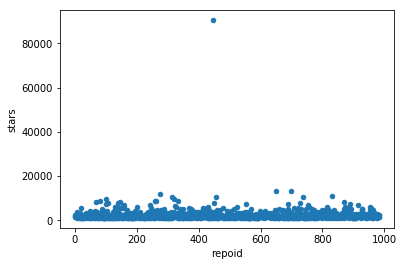

```python
df_final_user_repo_star_repo_id_merge.plot.scatter(x='repoid', y = 'stars')
```

## Above graph shows one repository with stars greater than 80,000 and hence we can consider this as an outlier and remove it from dataset.

## Below we removed it and get more general plot after removing it.

```python
df_final_user_repo_star_repo_id_merge.drop(df_final_user_repo_star_repo_id_merge.loc[df_final_user_repo_star_repo_id_merge['stars']== df_final_user_repo_star_repo_id_merge['stars'].max() ].index, inplace=True)
```

## Plot after removing the outlier

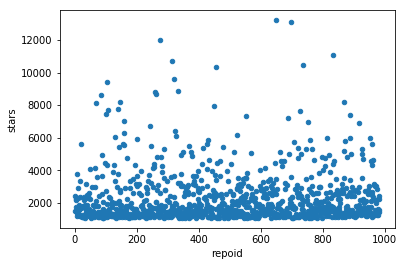

```python
df_final_user_repo_star_repo_id_merge.plot.scatter(x='repoid', y = 'stars')
```

## We also see that now the dataframe has more even spreadout if you check the 25%, 50% and 75% statistics

```python
df_final_user_repo_star_repo_id_merge.describe()
```

|  | repoid | stars |
| --- | --- | --- |
| count | 999.000000 | 999.000000 |
| mean | 493.501502 | 2294.962963 |
| std | 284.742586 | 1593.578076 |
| min | 0.000000 | 1083.000000 |
| 25% | 246.500000 | 1320.000000 |
| 50% | 496.000000 | 1692.000000 |
| 75% | 740.500000 | 2669.500000 |
| max | 983.000000 | 13208.000000 |

## Here below we copy the current dataframe to get a new dataframe which we need for searching later for recommendations

```python
df_final_user_repo_star_repo_id_merge_copy = df_final_user_repo_star_repo_id_merge.copy(deep=True)
```

```python
df_final_user_repo_star_repo_id_merge_copy.head()
```

|  | repoid | repo_name | user | stars | user_repo_name |
| --- | --- | --- | --- | --- | --- |
| 0 | 0 | atswift-2016-resources | atConf | 1504 | atConf/atswift-2016-resources |
| 1 | 1 | npm-check | dylang | 2438 | dylang/npm-check |
| 2 | 2 | openage | SFTtech | 1739 | SFTtech/openage |
| 3 | 3 | react-demos | ruanyf | 2167 | ruanyf/react-demos |
| 4 | 4 | Hystrix | Netflix | 1505 | Netflix/Hystrix |

## We just checked if we have got the correct unique repositories as they have to be unique

```python
    df_final_user_repo_star_repo_id_merge_copy['user_repo_name'].unique()
```

```
array(['atConf/atswift-2016-resources', 'dylang/npm-check',
       'SFTtech/openage', 'ruanyf/react-demos', 'Netflix/Hystrix',
       'BradLarson/GPUImage2', 'carekit-apple/CareKit',
       'prometheus/prometheus', 'samshadwell/TrumpScript',
       'YouXianMing/YoCelsius', 'pkmital/tensorflow_tutorials',
       'jondot/awesome-react-native',
       'kesenhoo/android-training-course-in-chinese',
       'bvaughn/react-virtualized', 'xiekw2010/react-native-gitfeed',
       'danylovolokh/VideoPlayerManager', 'HunterLarco/voxel.css',
       'danialfarid/ng-file-upload', 'Croteam-official/Serious-Engine',
       'jlevy/the-art-of-command-line', 'containous/traefik',
       'lapwinglabs/x-ray', 'futurice/pepperoni-app-kit',
       'hilen/TSWeChat', 'iammert/MaterialIntroView', 'composer/composer',
       'tc39/ecma262', 'JacksonTian/fks', 'programthink/zhao',
       'astaxie/build-web-application-with-golang',
       'shekhargulati/52-technologies-in-2016',
       'NativeScript/NativeScript', 'gaearon/normalizr', 'phodal/growth',
       'sqlitebrowser/sqlitebrowser',
       'forkingdog/UITableView-FDTemplateLayoutCell',
       'philipwalton/flexbugs', 'adam-p/markdown-here',
       'ryanflorence/react-project', 'eladnava/mailgen',
       'sindresorhus/awesome-electron', 'Homebrew/homebrew',
       'mathiasbynens/dotfiles', 'IonicaBizau/scrape-it',
       'deeplearning4j/deeplearning4j', 'h4cc/awesome-elixir',
       'grafana/grafana', 'Karumi/Rosie', 'google/flatbuffers',
       'madmalik/mononoki', 'eliangcs/http-prompt', 'Moya/Moya',
       'kriskowal/q', 'FormidableLabs/radium',
       'realpython/discover-flask', 'onevcat/VVDocumenter-Xcode',
       'PhilJay/MPAndroidChart', 'jobbole/awesome-java-cn',
       'fisherman/fisherman', 'facebook/relay', 'LukyVj/family.scss',
       'cht8687/You-Dont-Need-Lodash-Underscore',
       'react-bootstrap/react-bootstrap', 'pedrovgs/EffectiveAndroidUI',
       'aksonov/react-native-router-flux', 'AFNetworking/AFNetworking',
       'syl20bnr/spacemacs', 'getlantern/lantern', 'ariya/phantomjs',
       'geeeeeeeeek/WeChatLuckyMoney', 'SVProgressHUD/SVProgressHUD',
       'amayne/SwiftString', 'fastlane/fastlane', 'google/dagger',
       'rwaldron/johnny-five', 'ipfs/ipfs',
       'ChenYilong/iOSInterviewQuestions', 'iCHAIT/awesome-osx',
       'tensorflow/skflow', 'ZhyTeam/ZhyCore', 'antontarasenko/smq',
       'DKirwan/calendar-heatmap', 'magicalpanda/MagicalRecord',
```

[output cut: 380 more lines]

```
       'ReactjsProgram/react-fundamentals-curriculum',
       'Aufree/trip-to-iOS', 'alexjc/neural-doodle', 'rabbitmq/internals',
       'santinic/how2', 'jdg/MBProgressHUD',
       'FezVrasta/bootstrap-material-design', 'reactjs/redux',
       'rackt/redux', 'kazzkiq/balloon.css', 'zhengwenming/WMPlayer',
       'vsouza/awesome-ios', 'oblador/react-native-vector-icons',
       'hacksalot/HackMyResume', '0x5e/wechat-deleted-friends',
       'Yalantis/uCrop', 'uber-common/cpustat', 'keithwhor/nodal',
       'mattkrick/meatier', 'jessesquires/JSQMessagesViewController',
       'tensorflow/playground', 'gaearon/react-hot-loader',
       'necolt/Swifton', 'ecomfe/echarts', 'getgrav/grav', 'kataras/iris',
       'jtoy/awesome-tensorflow', 'symfony/symfony', 'github/scientist',
       'hemanth/functional-programming-jargon', 'garnele007/SwiftOCR',
       'MarshallOfSound/Google-Play-Music-Desktop-Player-UNOFFICIAL-',
       'tastejs/todomvc', 'google/fonts', 'powerline/fonts'], dtype=object)
```

```python
df_final_user_repo_star_repo_id_merge_copy.head()
```

|  | repoid | repo_name | user | stars | user_repo_name |
| --- | --- | --- | --- | --- | --- |
| 0 | 0 | atswift-2016-resources | atConf | 1504 | atConf/atswift-2016-resources |
| 1 | 1 | npm-check | dylang | 2438 | dylang/npm-check |
| 2 | 2 | openage | SFTtech | 1739 | SFTtech/openage |
| 3 | 3 | react-demos | ruanyf | 2167 | ruanyf/react-demos |
| 4 | 4 | Hystrix | Netflix | 1505 | Netflix/Hystrix |

```python
df_final_user_repo_star_1.drop(df_final_user_repo_star_1.loc[df_final_user_repo_star_1['stars'] == df_final_user_repo_star_1['stars'].max() ].index, inplace=True)
#df_final_user_repo_star_1.drop(df_final_user_repo_star_1.loc[df_final_user_repo_star_1['stars'] > 6000 ].index, inplace=True)
```

## Now that we have repoid and correct repositories, we merge it with user ids to get ids concatenated to the new dataframe

```python
df_final_user_repo_star_2 = pandas.merge(df_repo_id, df_final_user_repo_star_1, how='inner', on=['repo_name'])
```

```python
df_final_user_repo_star_2.head()
```

|  | repoid | repo_name | userid | user | stars | user_repo_name |
| --- | --- | --- | --- | --- | --- | --- |
| 0 | 0 | atswift-2016-resources | 707 | atConf | 1504 | atConf/atswift-2016-resources |
| 1 | 1 | npm-check | 598 | dylang | 2438 | dylang/npm-check |
| 2 | 2 | openage | 98 | SFTtech | 1739 | SFTtech/openage |
| 3 | 3 | react-demos | 487 | ruanyf | 2167 | ruanyf/react-demos |
| 4 | 4 | Hystrix | 434 | Netflix | 1505 | Netflix/Hystrix |

```python
df_final_user_repo_star_2.describe()
```

|  | repoid | userid | stars |
| --- | --- | --- | --- |
| count | 999.000000 | 999.000000 | 999.000000 |
| mean | 493.501502 | 412.306306 | 2294.962963 |
| std | 284.742586 | 236.843268 | 1593.578076 |
| min | 0.000000 | 0.000000 | 1083.000000 |
| 25% | 246.500000 | 204.500000 | 1320.000000 |
| 50% | 496.000000 | 426.000000 | 1692.000000 |
| 75% | 740.500000 | 612.500000 | 2669.500000 |
| max | 983.000000 | 827.000000 | 13208.000000 |

```python
print(df_final_user_repo_star_2['stars'].max())
```

```
13208
```

```python
df_final_user_repo_star_2.drop(df_final_user_repo_star_2.loc[df_final_user_repo_star_2['stars'] == df_final_user_repo_star_2['stars'].max() ].index, inplace=True)
```

```python
df_final_user_repo_star_2.describe()
```

|  | repoid | userid | stars |
| --- | --- | --- | --- |
| count | 998.000000 | 998.000000 | 998.000000 |
| mean | 493.343687 | 412.166333 | 2284.028056 |
| std | 284.841636 | 236.920672 | 1556.427252 |
| min | 0.000000 | 0.000000 | 1083.000000 |
| 25% | 246.250000 | 204.250000 | 1320.000000 |
| 50% | 495.500000 | 425.500000 | 1691.000000 |
| 75% | 740.750000 | 612.750000 | 2666.750000 |
| max | 983.000000 | 827.000000 | 13125.000000 |

## Here in this approach we used SVD standard library which expects input in the format of 'User', 'Item' and 'Rating', so do the next processing steps to create the dataframe into required labels and parameters

```python
df_final_user_repo_star_v1 = pandas.DataFrame(df_final_user_repo_star_2, columns=['userid','repoid', 'stars'])
```

```python
df_final_user_repo_star_v2 = df_final_user_repo_star_v1.rename(index = str, columns={'userid':'user', 'repoid':'item', 'stars':'rating'})
```

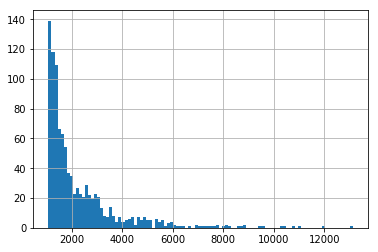

```python
df_final_user_repo_star_2['stars'].hist( bins = 100)
```

## Plot for 'repoid' vs 'stars'

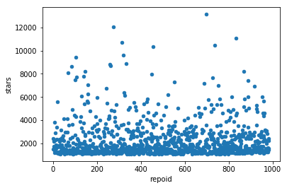

```python
df_final_user_repo_star_2.plot.scatter(x='repoid', y = 'stars')
```

## Plot for 'userid' vs 'stars'

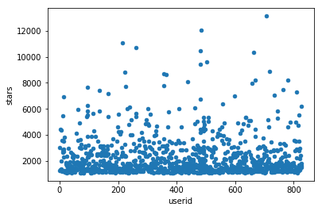

```python
df_final_user_repo_star_2.plot.scatter(x='userid', y = 'stars')
```

```python
df_final_user_repo_star_v2.describe()
```

|  | user | item | rating |
| --- | --- | --- | --- |
| count | 998.000000 | 998.000000 | 998.000000 |
| mean | 412.166333 | 493.343687 | 2284.028056 |
| std | 236.920672 | 284.841636 | 1556.427252 |
| min | 0.000000 | 0.000000 | 1083.000000 |
| 25% | 204.250000 | 246.250000 | 1320.000000 |
| 50% | 425.500000 | 495.500000 | 1691.000000 |
| 75% | 612.750000 | 740.750000 | 2666.750000 |
| max | 827.000000 | 983.000000 | 13125.000000 |

## As seen above still the 'stars' are not in normalized range, so we have used 'divide by mean' strategy to normalize the data for 'stars'

```python
 df_final_user_repo_star_v3 = df_final_user_repo_star_v2.copy(deep=True)
# rating_max = df_final_user_repo_star_v2.rating.max()
# rating_min = df_final_user_repo_star_v2.rating.min()
rating_mean = df_final_user_repo_star_v2.rating.mean()
df_final_user_repo_star_v3['rating'] = df_final_user_repo_star_v3.apply(lambda row: row['rating']/rating_mean, axis=1)
```

```python
df_final_user_repo_star_v3.describe()
```

|  | user | item | rating |
| --- | --- | --- | --- |
| count | 998.000000 | 998.000000 | 998.000000 |
| mean | 412.166333 | 493.343687 | 1.000000 |
| std | 236.920672 | 284.841636 | 0.681440 |
| min | 0.000000 | 0.000000 | 0.474162 |
| 25% | 204.250000 | 246.250000 | 0.577926 |
| 50% | 425.500000 | 495.500000 | 0.740359 |
| 75% | 612.750000 | 740.750000 | 1.167564 |
| max | 827.000000 | 983.000000 | 5.746427 |

```python
df_final_user_repo_star_v3.head()
```

|  | user | item | rating |
| --- | --- | --- | --- |
| 0 | 707 | 0 | 0.658486 |
| 1 | 598 | 1 | 1.067412 |
| 2 | 98 | 2 | 0.761374 |
| 3 | 487 | 3 | 0.948762 |
| 4 | 434 | 4 | 0.658924 |

## Training multiple models :

1. SVD
2. KNNBasic
3. CoClustering
4. SlopeOne

## SVD Implementation without train, test split

```python
listOfRMSE = []
models = []
```

```python
from surprise import Reader, Dataset, SVD, SVDpp, evaluate, accuracy
from surprise.model_selection import train_test_split
reader = Reader(line_format='user item rating', sep=',', rating_scale=(0,6))
df_temp1 = df_final_user_repo_star_v3.copy(deep=True);
data = Dataset.load_from_df(df_temp1, reader)
# Test that surprise is working by running SVD on the dataset

# We'll use the famous SVD algorithm.
algo = SVD(n_factors= 100, n_epochs= 20, biased=True, init_std_dev=0.1, lr_all=0.005)

# Train the algorithm on the trainset, and predict ratings for the testset
trainset = data.build_full_trainset()

algo.fit(trainset)

testset = trainset.build_anti_testset()
svd_predictions = algo.test(testset)

rmse_svd = accuracy.rmse(svd_predictions)
print(rmse_svd)
listOfRMSE.append(rmse_svd)
models.append('SVD')
```

```
RMSE: 0.1308
0.13079860943285757
```

## SVD Implementation with KFold Cross Validators

```python
from surprise.model_selection import KFold
# define a cross-validation iterator
n_splits = 3
kf = KFold(n_splits=3)

algo = SVD()
tempRMSE = 0
for trainset, testset in kf.split(data):

    # train and test algorithm.
    algo.fit(trainset)
    predictions = algo.test(testset)

    # Compute and print Root Mean Squared Error
    accuracy.rmse(predictions, verbose=True)
    tempRMSE += accuracy.rmse(predictions, verbose=False)

listOfRMSE.append(tempRMSE/n_splits)
models.append('SVD with KFold')
```

```
RMSE: 0.6925
RMSE: 0.7462
RMSE: 0.5939
```

## KNNBasic Implementation using 'pearson' similarity

```python
# We'll use the famous SVD algorithm.
from surprise import KNNBasic

df_knnbasic = df_final_user_repo_star_v3.copy(deep=True);
dataknnbasic = Dataset.load_from_df(df_knnbasic, reader)

sim_options = {
    'name': 'pearson'
}

algo1 = KNNBasic(sim_options = sim_options, k=40,min_k=1)

# Train the algorithm on the trainset, and predict ratings for the testset
trainset1 = dataknnbasic.build_full_trainset()

algo1.fit(trainset1)

testset1 = trainset1.build_anti_testset()
KNNBasic_pearson_predictions = algo1.test(testset1)

accuracy.rmse(KNNBasic_pearson_predictions)
listOfRMSE.append(accuracy.rmse(KNNBasic_pearson_predictions))
models.append('KNN with Pearson')
```

```
Computing the pearson similarity matrix...
Done computing similarity matrix.
RMSE: 0.0010
RMSE: 0.0010
```

## KNNBasic Implementation using 'cosine' similarity

```python
sim_options = {
    'name': 'cosine'
}

algo1 = KNNBasic(sim_options = sim_options, k=40,min_k=1)

# Train the algorithm on the trainset, and predict ratings for the testset
trainset1 = dataknnbasic.build_full_trainset()

algo1.fit(trainset1)

testset1 = trainset1.build_anti_testset()
KNNBasic_cosine_predictions = algo1.test(testset1)

cosine_rmse = accuracy.rmse(KNNBasic_cosine_predictions)
listOfRMSE.append(cosine_rmse)
models.append('KNN with cosine')
```

```
Computing the cosine similarity matrix...
Done computing similarity matrix.
RMSE: 0.0044
```

## CoClustering Implementation

```python
# We'll use the famous SVD algorithm.
from surprise import CoClustering

df_CoClustering = df_final_user_repo_star_v3.copy(deep=True);
dataCoClustering = Dataset.load_from_df(df_CoClustering, reader)


coClustering = CoClustering(n_cltr_u=3, n_cltr_i=3, n_epochs=20)

# Train the algorithm on the trainset, and predict ratings for the testset
trainsetcoClustering  = dataCoClustering.build_full_trainset()

coClustering.fit(trainsetcoClustering)

testcoClustering = trainsetcoClustering.build_anti_testset()
predictionscoClustering = coClustering.test(testcoClustering)

accuracy.rmse(predictionscoClustering)


listOfRMSE.append(accuracy.rmse(predictionscoClustering))
models.append('CoClustering')
```

```
RMSE: 1.0057
RMSE: 1.0057
```

## SlopeOne Implementation

```python
from surprise import SlopeOne
slopeOne = SlopeOne()

# Train the algorithm on the trainset, and predict ratings for the testset
trainsetslopeOne  = dataCoClustering.build_full_trainset()

slopeOne.fit(trainsetslopeOne)

testslopeOne = trainsetslopeOne.build_anti_testset()
predictionsslopeOne = slopeOne.test(testslopeOne)

accuracy.rmse(predictionsslopeOne)

listOfRMSE.append(accuracy.rmse(predictionsslopeOne))
models.append('SlopeOne')
```

```
RMSE: 0.6186
RMSE: 0.6186
```

```python
models
```

```
['SVD',
 'SVD with KFold',
 'KNN with Pearson',
 'KNN with cosine',
 'CoClustering',
 'SlopeOne']
```

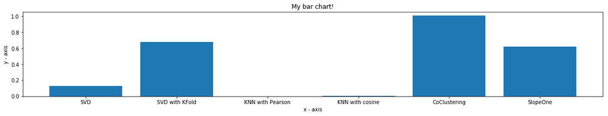

```python
import matplotlib.pyplot as plt
plt.rcParams["figure.figsize"] = (20,3)
# x-coordinates of left sides of bars
Algorithms = [1, 2, 3, 4, 5, 6]

# heights of bars
RMSE = listOfRMSE

# labels for bars
label = models

# plotting a bar chart
plt.bar(Algorithms, RMSE, tick_label = label,
		width = 0.8)

# naming the x-axis
plt.xlabel('x - axis')
# naming the y-axis
plt.ylabel('y - axis')
# plot title
plt.title('My bar chart!')

# function to show the plot
plt.show()
```

## Getting top 20 recommendations (We are getting 20 because we want to do further Social Analysis of this data and see if we can do community detections)

```python
from collections import defaultdict
def get_top_n(predictions, n=10):

    # First map the predictions to each user.
    top_n = defaultdict(list)
    for uid, iid, true_r, est, _ in predictions:
        ## Multiplying by mean to predicted rating i.e est as we had first divided by mean for normalizing
        top_n[uid].append((iid, est*rating_mean))

    # Then sort the predictions for each user and retrieve the k highest ones.
    for uid, user_ratings in top_n.items():
        user_ratings.sort(key=lambda x: x[1], reverse=True)
        top_n[uid] = user_ratings[:n]

    return top_n
```

## For each user we give out top 20 recommended repositories thus our second use case is implemented firstly with SVD which gave pretty diverse recommendations compared to KNN

```python
top_n = get_top_n(KNNBasic_pearson_predictions, n=20)

# Print the recommended items for each user
for uid, user_ratings in top_n.items():
    print(uid, [iid for (iid, _) in user_ratings])
```

```
707 [1, 2, 3, 4, 5, 6, 7, 8, 9, 10, 11, 12, 13, 14, 15, 16, 17, 18, 19, 20]
598 [0, 2, 3, 4, 5, 6, 7, 8, 9, 10, 11, 12, 13, 14, 15, 16, 17, 18, 19, 20]
98 [0, 1, 3, 4, 5, 6, 7, 8, 9, 10, 11, 12, 13, 14, 15, 16, 17, 18, 19, 20]
487 [0, 1, 2, 4, 5, 6, 7, 8, 9, 10, 11, 12, 13, 14, 15, 16, 17, 18, 19, 20]
434 [0, 1, 2, 3, 5, 6, 7, 8, 9, 10, 11, 12, 13, 14, 15, 16, 17, 18, 19, 20]
97 [0, 1, 2, 3, 4, 6, 7, 8, 9, 10, 11, 12, 13, 14, 15, 16, 17, 18, 19, 20]
207 [0, 1, 2, 3, 4, 5, 7, 8, 9, 10, 11, 12, 13, 14, 15, 16, 17, 18, 19, 20]
5 [0, 1, 2, 3, 4, 5, 6, 8, 9, 10, 11, 12, 13, 14, 15, 16, 17, 18, 19, 20]
16 [0, 1, 2, 3, 4, 5, 6, 7, 9, 10, 11, 12, 13, 14, 15, 16, 17, 18, 19, 20]
199 [0, 1, 2, 3, 4, 5, 6, 7, 8, 10, 11, 12, 13, 14, 15, 16, 17, 18, 19, 20]
637 [0, 1, 2, 3, 4, 5, 6, 7, 8, 9, 11, 12, 13, 14, 15, 16, 17, 18, 19, 20]
701 [0, 1, 2, 3, 4, 5, 6, 7, 8, 9, 10, 12, 13, 14, 15, 16, 17, 18, 19, 20]
297 [0, 1, 2, 3, 4, 5, 6, 7, 8, 9, 10, 11, 13, 14, 15, 16, 17, 18, 19, 20]
798 [0, 1, 2, 3, 4, 5, 6, 7, 8, 9, 10, 11, 12, 14, 15, 16, 17, 18, 19, 20]
381 [0, 1, 2, 3, 4, 5, 6, 7, 8, 9, 10, 11, 12, 13, 15, 16, 17, 18, 19, 20]
```

[output cut: 811 more lines]

```python
top_n = get_top_n(svd_predictions, n=20)

# Print the recommended items for each user
for uid, user_ratings in top_n.items():
    print(uid, [iid for (iid, _) in user_ratings])
```

```
707 [275, 315, 869, 552, 697, 457, 319, 263, 449, 67, 736, 887, 832, 334, 674, 807, 478, 707, 145, 758]
598 [697, 376, 275, 457, 688, 260, 319, 728, 263, 467, 154, 888, 107, 449, 525, 832, 630, 369, 600, 672]
98 [736, 697, 832, 334, 315, 434, 275, 611, 457, 552, 244, 255, 320, 888, 728, 721, 160, 67, 869, 873]
487 [697, 135, 888, 158, 975, 328, 637, 822, 275, 873, 139, 67, 107, 869, 100, 825, 319, 264, 549, 457]
434 [67, 315, 244, 334, 319, 102, 275, 525, 457, 449, 736, 145, 395, 279, 899, 234, 888, 160, 310, 263]
97 [275, 139, 457, 832, 263, 697, 260, 736, 334, 160, 688, 478, 157, 431, 67, 953, 728, 754, 100, 140]
207 [334, 288, 873, 196, 238, 688, 457, 697, 167, 736, 376, 807, 130, 83, 260, 888, 767, 328, 255, 263]
5 [697, 869, 431, 599, 260, 457, 315, 280, 107, 674, 580, 879, 275, 449, 256, 661, 785, 102, 19, 736]
16 [275, 697, 832, 319, 315, 83, 260, 552, 928, 457, 246, 754, 263, 814, 130, 449, 157, 67, 288, 100]
199 [697, 315, 832, 736, 102, 288, 275, 457, 661, 319, 728, 67, 928, 145, 449, 334, 244, 137, 1, 100]
637 [315, 107, 697, 869, 145, 275, 102, 319, 916, 736, 396, 407, 160, 381, 754, 832, 395, 365, 552, 973]
701 [697, 887, 315, 832, 260, 525, 457, 449, 102, 674, 319, 263, 67, 819, 814, 869, 823, 407, 376, 763]
297 [83, 275, 319, 457, 478, 970, 697, 758, 688, 449, 736, 334, 260, 139, 160, 953, 846, 197, 601, 278]
798 [832, 315, 697, 275, 736, 449, 819, 814, 434, 107, 928, 139, 645, 707, 158, 773, 887, 548, 421, 869]
381 [697, 319, 947, 315, 869, 328, 767, 275, 263, 97, 916, 548, 832, 736, 431, 199, 260, 787, 17, 952]
```

[output cut: 811 more lines]

## Helper function program to create a list of users with repository and correspoding stars for further graph plotting and social analysis

```python
count = 0
user_graph_repo_stars_list = []
for uid, user_ratings in top_n.items():
    count += 1
    if count > 3:
        break
    graph_list1 = []
    for repoid, stars_computed in user_ratings:
        #print(repoid)
        graph_dict = {
            "repoid": repoid,
            "stars":stars_computed
        }
        graph_list1.append(graph_dict)
        temp = {
            "user": uid,
            "list": graph_list1
        }
    user_graph_repo_stars_list.append(temp)
    #print(uid, [iid for (iid, _) in user_ratings])
```

## Setting index on dataframe to search with 'repoid'

```python
df_final_user_repo_star_repo_id_merge_copy1 = df_final_user_repo_star_repo_id_merge_copy.copy(deep=True)
df_final_user_repo_star_repo_id_merge_copy1.set_index('repoid', inplace=True)
```

## Below we create final list with which we do the social analysis of user, repository and language.

## we have implemented this as an extended functionality for study purpose so only first three users with corresponding top 20 recommended repositories and predicted stars is used

```python
graph_final_list_user_reponame = []
for i in user_graph_repo_stars_list:
    user = i['user']
    #print(df_user_id.loc[user]['user'])
    repos = i['list']

    temp_list = []
    for j in repos:
        id = j['repoid']
        stars = j['stars']
        temp = df_final_user_repo_star_repo_id_merge_copy1.loc[id]['user_repo_name']
        if type(temp) == str:
            repo_dict = {
                "reponame": temp,
                "stars": stars
            }
            temp_list.append(repo_dict)

    user_dict = {
        "user": user,
        "list": temp_list
    }
    graph_final_list_user_reponame.append(user_dict)
```

```python
graph_final_list_user_reponame
```

```
[{'user': 707,
  'list': [{'reponame': 'braydie/HowToBeAProgrammer',
    'stars': 3217.6708883835013},
   {'reponame': 'tensorflow/tensorflow', 'stars': 3196.7337120850443},
   {'reponame': 'toddmotto/public-apis', 'stars': 3148.5610966963873},
   {'reponame': 'joshbuchea/HEAD', 'stars': 3140.4086441351733},
   {'reponame': 'ParsePlatform/parse-server', 'stars': 3089.9628511181045},
   {'reponame': 'loverajoel/jstips', 'stars': 3085.057618399449},
   {'reponame': 'airbnb/javascript', 'stars': 3062.8666897928447},
   {'reponame': 'DrkSephy/es6-cheatsheet', 'stars': 3017.2970073339707},
   {'reponame': 'getlantern/lantern', 'stars': 2975.1494564951226},
   {'reponame': 'facebook/react', 'stars': 2952.2753896842933},
   {'reponame': 'hollance/swift-algorithm-club', 'stars': 2917.5189098057126},
   {'reponame': 'sindresorhus/awesome', 'stars': 2875.260734999504},
   {'reponame': 'vhf/free-programming-books', 'stars': 2872.389264486914},
   {'reponame': 'google/material-design-lite', 'stars': 2872.1051159498434},
   {'reponame': 'vurtun/nuklear', 'stars': 2855.369480538022},
   {'reponame': 'CRYTEK-CRYENGINE/CRYENGINE', 'stars': 2831.7956678720757},
   {'reponame': 'jcjohnson/neural-style', 'stars': 2801.1551078091643},
   {'reponame': 'jiahaog/nativefier', 'stars': 2759.7423839985686}]},
 {'user': 598,
  'list': [{'reponame': 'joshbuchea/HEAD', 'stars': 3276.1551614590385},
   {'reponame': 'rg3/youtube-dl', 'stars': 3138.0009796147556},
   {'reponame': 'braydie/HowToBeAProgrammer', 'stars': 3118.805838354024},
   {'reponame': 'ParsePlatform/parse-server', 'stars': 3091.878408219221},
   {'reponame': 'Rochester-NRT/AlphaGo', 'stars': 3061.8379045031406},
   {'reponame': 'vuejs/vue', 'stars': 3014.315225690904},
   {'reponame': 'loverajoel/jstips', 'stars': 2998.751085152222},
   {'reponame': 'getify/You-Dont-Know-JS', 'stars': 2997.2484210221332},
   {'reponame': 'airbnb/javascript', 'stars': 2971.903067538708},
   {'reponame': 'coryhouse/react-slingshot', 'stars': 2963.9705120056337},
   {'reponame': 'tensorflow/models', 'stars': 2961.0640510550447},
   {'reponame': 'jgthms/bulma', 'stars': 2922.612218367164},
   {'reponame': 'googlesamples/android-architecture',
    'stars': 2903.2762176312863},
   {'reponame': 'DrkSephy/es6-cheatsheet', 'stars': 2885.4869010370285},
   {'reponame': 'ptmt/react-native-desktop', 'stars': 2877.4410557267915},
   {'reponame': 'sindresorhus/awesome', 'stars': 2873.632148758929},
   {'reponame': 'segmentio/nightmare', 'stars': 2872.044234668783},
   {'reponame': 'dmlc/mxnet', 'stars': 2870.151946342758},
   {'reponame': 'viljamis/feature.js', 'stars': 2862.8019235288252},
   {'reponame': 'hashicorp/consul', 'stars': 2841.226131250047}]},
 {'user': 98,
  'list': [{'reponame': 'facebook/react', 'stars': 3490.208810082233},
   {'reponame': 'joshbuchea/HEAD', 'stars': 3088.392386237391},
   {'reponame': 'sindresorhus/awesome', 'stars': 3078.131256861562},
   {'reponame': 'vhf/free-programming-books', 'stars': 3066.5523097362293},
   {'reponame': 'tensorflow/tensorflow', 'stars': 3065.35061215057},
   {'reponame': 'aosabook/500lines', 'stars': 3035.123069859259},
   {'reponame': 'braydie/HowToBeAProgrammer', 'stars': 2976.012637557955},
   {'reponame': 'kyleneideck/BackgroundMusic', 'stars': 2957.7651331096076},
   {'reponame': 'ParsePlatform/parse-server', 'stars': 2950.580888659087},
   {'reponame': 'facebook/draft-js', 'stars': 2913.334088780663},
   {'reponame': 'google/seesaw', 'stars': 2904.212778879831},
   {'reponame': 'fulldecent/system-bus-radio', 'stars': 2897.160689695968},
   {'reponame': 'jgthms/bulma', 'stars': 2877.9577041532866},
   {'reponame': 'getify/You-Dont-Know-JS', 'stars': 2861.8788019228055},
   {'reponame': 'vinta/awesome-python', 'stars': 2858.5427874264897},
   {'reponame': 'apple/swift', 'stars': 2816.4793277970866},
   {'reponame': 'getlantern/lantern', 'stars': 2810.2776853563196},
   {'reponame': 'toddmotto/public-apis', 'stars': 2808.2051569587197},
   {'reponame': 'atom/atom', 'stars': 2805.7891539358643}]}]
```

```python
user_list_for_graph = []
repo_list_for_graph = []
stars_list_for_graph = []
for row in graph_final_list_user_reponame:
    index = len(row['list'])
    for i in range(index):
        user_list_for_graph.append(row['user'])
        repo_list_for_graph.append(row['list'][i]['reponame'])
        stars_list_for_graph.append(row['list'][i]['stars'])
```

```python
repository_url = []
for val in repo_list_for_graph:
    temp = "https://github.com/" + val
    repository_url.append(temp)

repository_url
```

```
['https://github.com/braydie/HowToBeAProgrammer',
 'https://github.com/tensorflow/tensorflow',
 'https://github.com/toddmotto/public-apis',
 'https://github.com/joshbuchea/HEAD',
 'https://github.com/ParsePlatform/parse-server',
 'https://github.com/loverajoel/jstips',
 'https://github.com/airbnb/javascript',
 'https://github.com/DrkSephy/es6-cheatsheet',
 'https://github.com/getlantern/lantern',
 'https://github.com/facebook/react',
 'https://github.com/hollance/swift-algorithm-club',
 'https://github.com/sindresorhus/awesome',
 'https://github.com/vhf/free-programming-books',
 'https://github.com/google/material-design-lite',
 'https://github.com/vurtun/nuklear',
 'https://github.com/CRYTEK-CRYENGINE/CRYENGINE',
 'https://github.com/jcjohnson/neural-style',
 'https://github.com/jiahaog/nativefier',
 'https://github.com/joshbuchea/HEAD',
 'https://github.com/rg3/youtube-dl',
 'https://github.com/braydie/HowToBeAProgrammer',
 'https://github.com/ParsePlatform/parse-server',
 'https://github.com/Rochester-NRT/AlphaGo',
 'https://github.com/vuejs/vue',
 'https://github.com/loverajoel/jstips',
 'https://github.com/getify/You-Dont-Know-JS',
 'https://github.com/airbnb/javascript',
 'https://github.com/coryhouse/react-slingshot',
 'https://github.com/tensorflow/models',
 'https://github.com/jgthms/bulma',
 'https://github.com/googlesamples/android-architecture',
 'https://github.com/DrkSephy/es6-cheatsheet',
 'https://github.com/ptmt/react-native-desktop',
 'https://github.com/sindresorhus/awesome',
 'https://github.com/segmentio/nightmare',
 'https://github.com/dmlc/mxnet',
 'https://github.com/viljamis/feature.js',
 'https://github.com/hashicorp/consul',
 'https://github.com/facebook/react',
 'https://github.com/joshbuchea/HEAD',
 'https://github.com/sindresorhus/awesome',
 'https://github.com/vhf/free-programming-books',
 'https://github.com/tensorflow/tensorflow',
 'https://github.com/aosabook/500lines',
 'https://github.com/braydie/HowToBeAProgrammer',
 'https://github.com/kyleneideck/BackgroundMusic',
 'https://github.com/ParsePlatform/parse-server',
 'https://github.com/facebook/draft-js',
 'https://github.com/google/seesaw',
 'https://github.com/fulldecent/system-bus-radio',
 'https://github.com/jgthms/bulma',
 'https://github.com/getify/You-Dont-Know-JS',
 'https://github.com/vinta/awesome-python',
 'https://github.com/apple/swift',
 'https://github.com/getlantern/lantern',
 'https://github.com/toddmotto/public-apis',
 'https://github.com/atom/atom']
```

```python
repo_stars_dataframe = pandas.DataFrame({'User':user_list_for_graph, 'URL':repository_url, 'Repos':repo_list_for_graph, 'Stars':stars_list_for_graph})
```

```python
repo_stars_dataframe.to_csv("repo_stars_dataframe.csv", sep='\t')
```

# Use case 3: Network Analysis

## Import necessary libraries

```python
import pandas as pd
import igraph
```

## Read the input file and drop the unnecessary columns

```python
repo_stars_dataframe = pd.read_csv('repo_stars_dataframe.csv', sep='\t')
repo_stars_dataframe.drop(repo_stars_dataframe.columns[0], axis = 1, inplace=True)
repo_stars_dataframe.head()
```

[output not shown]

## Create the list of nodes which has highest watch count

```python
indexList = [0]
for i in range(len(repo_stars_dataframe)-1):
    if repo_stars_dataframe['User'][i] != repo_stars_dataframe['User'][i+1]:
        indexList.append(i+1)
```

## Add the nodes to graph

```python
g = igraph.Graph()
graph_user = repo_stars_dataframe['User']
graph_repos_url = repo_stars_dataframe['URL']
graph_repos = repo_stars_dataframe['Repos']
graph_watchers = repo_stars_dataframe['Stars']

index = 0
for row in range(len(repo_stars_dataframe)):
    g.add_vertex(name=graph_repos_url[index],
            label=graph_repos[index],
            watchers=int(graph_watchers[0]))
    index += 1
```

## Make repo of rows having highest watch count for every user

```python
repo1 = repo_stars_dataframe.copy(deep=True)
dropIndexList = []
for index in range(len(repo_stars_dataframe)):
    if index not in indexList:
        dropIndexList.append(index)

repo1.drop(dropIndexList, inplace=True)
repo1
```

[output not shown]

## Connect the nodes on the basis of watch count

```python
edges_dataframe = pd.merge(repo1, repo_stars_dataframe, how='inner', on=['User'])
repo1 = edges_dataframe['URL_x']
repo2 = edges_dataframe['URL_y']
weight = edges_dataframe['Stars_x'] * edges_dataframe['Stars_y']

index = 0
for row in range(len(edges_dataframe)):
    g.add_edge(repo1[index], repo2[index],
            weight=float(weight[index]))
    index += 1
```

## Export the graph file to visualize using Gephi

```python
g.write('repos.gml')
g.summary()
```

[output not shown]

## Exported file repos.gml is processed in Gephi to generate the graph

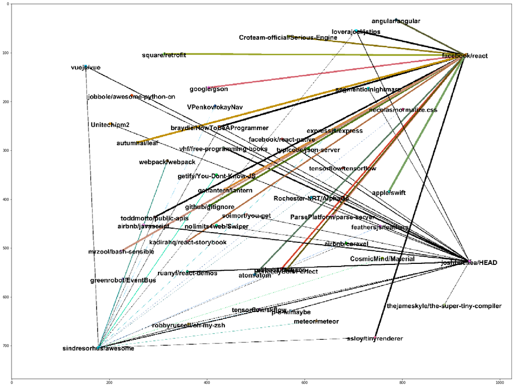

```python
%pylab inline
import matplotlib.pyplot as plt
import matplotlib.image as mpimg
figure(figsize = (50,20))
img=mpimg.imread('graph.png')
imgplot = plt.imshow(img)
plt.show()
```

## References:

1. Surprise library documenation: https://surprise.readthedocs.io/en/stable/getting_started.html
2. Nick Becker's post on Matrix Factorization: https://beckernick.github.io/matrix-factorization-recommender/
3. Got first use case help from Lawrence Pang's analysis: https://www.kaggle.com/lpang36/recommend-languages-with-collaborative-filtering
4. Got third use case help from Corey Ford's analysis: https://github.com/coyotebush/github-network-analysis